# week_02_pca_penguins_revisit

## CMPINF 2120 - Week 02

### Revisit the Penguins data and Apply what we have learned about PCA

## Import Modules

```python
import numpy as np
import pandas as pd
import matplotlib.pyplot as plt

import seaborn as sns
```

## Read data

```python
penguins = sns.load_dataset('penguins')
```

```python
penguins.info()
```

```
<class 'pandas.core.frame.DataFrame'>
RangeIndex: 344 entries, 0 to 343
Data columns (total 7 columns):
 #   Column             Non-Null Count  Dtype
---  ------             --------------  -----
 0   species            344 non-null    object
 1   island             344 non-null    object
 2   bill_length_mm     342 non-null    float64
 3   bill_depth_mm      342 non-null    float64
 4   flipper_length_mm  342 non-null    float64
 5   body_mass_g        342 non-null    float64
 6   sex                333 non-null    object
dtypes: float64(4), object(3)
memory usage: 18.9+ KB
```

We already know we need to drop the missings to create the COMPLETE CASES for penguins.

```python
penguins_complete = penguins.dropna().copy()
```

```python
penguins_complete.isna().sum()
```

```
species              0
island               0
bill_length_mm       0
bill_depth_mm        0
flipper_length_mm    0
body_mass_g          0
sex                  0
dtype: int64
```

## Apply PCA

We know we need to STANDARDIZE the variables in the Penguins data set.

```python
from sklearn.preprocessing import StandardScaler
```

Extract the numeric features or columns from `penguins`.

```python
pens_features = penguins_complete.select_dtypes('number').copy()
```

```python
Xpens = StandardScaler(with_mean=True, with_std=True).fit_transform( pens_features )
```

Execute PCA on the standardized features.

```python
from sklearn.decomposition import PCA
```

Initialize and FIT the PCA object using the standardized features.

```python
Xpens.shape
```

```
(333, 4)
```

```python
pca_object = PCA().fit( Xpens )
```

```python
type( pca_object )
```

```
sklearn.decomposition._pca.PCA
```

We now need to TRANSFORM in order to calculate the PC scores!

```python
pc_scores_pens = pca_object.transform( Xpens )
```

Convert the PC scores NumPy array to a Pandas DataFrame.

```python
pc_scores_pens_df = pd.DataFrame( pc_scores_pens,
                                  columns=['pc%02d' % d for d in range(1, pc_scores_pens.shape[1]+1)])
```

```python
pc_scores_pens_df
```

|  | pc01 | pc02 | pc03 | pc04 |
| --- | --- | --- | --- | --- |
| 0 | -1.853593 | 0.032069 | -0.234902 | 0.528397 |
| 1 | -1.316254 | -0.443527 | -0.027470 | 0.401727 |
| 2 | -1.376605 | -0.161230 | 0.189689 | -0.528662 |
| 3 | -1.885288 | -0.012351 | -0.628873 | -0.472893 |
| 4 | -1.919981 | 0.817598 | -0.701051 | -0.196416 |
| ... | ... | ... | ... | ... |
| 328 | 1.997716 | -0.976771 | 0.379425 | 0.160892 |
| 329 | 1.832651 | -0.784510 | 0.240758 | -0.008955 |
| 330 | 2.751505 | 0.266556 | -0.419306 | 0.236256 |
| 331 | 1.713854 | -0.725875 | -0.262764 | 0.330004 |
| 332 | 2.018537 | 0.336554 | -0.155331 | 0.438802 |

333 rows × 4 columns

## Interpret PCA - variation

Begin by examining the variation for each PC score.

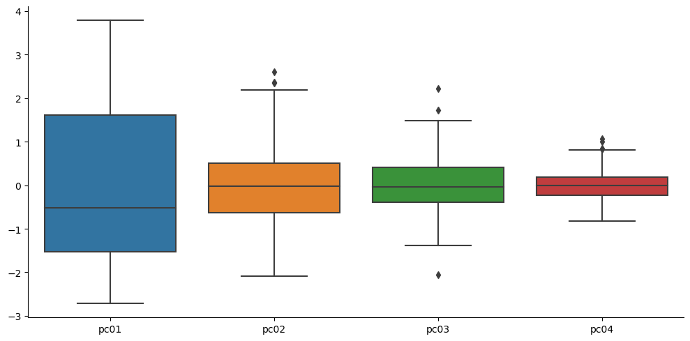

```python
sns.catplot(data = pc_scores_pens_df, kind='box', aspect=2)

plt.show()
```

Let's examine the eigenvalue plot to consider the number of effective variables contributing to each PC!

```python
def my_eigenvalue_plot( pca_object, figsize_use=None ):
    fig, ax = plt.subplots(figsize=figsize_use)

    ax.plot(np.arange(len( pca_object.explained_variance_ ) ) + 1,
            pca_object.explained_variance_,
            'bo-')

    ax.axhline(y=1, color='grey', linestyle='--')

    ax.set_xlabel('PC')
    ax.set_ylabel('Eigenvalue')

    plt.show()
```

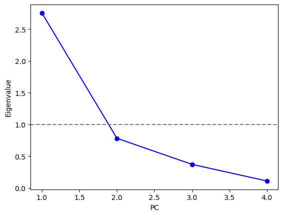

```python
my_eigenvalue_plot( pca_object )
```

Next, let's examine the SCREE PLOT to study the variance explained for each PC!

```python
def my_screeplot( pca_object, figsize_use=None ):
    fig, ax = plt.subplots(figsize=figsize_use)

    ax.plot( np.arange(len( pca_object.explained_variance_ratio_ ) ) + 1,
             pca_object.explained_variance_ratio_,
             'bo-' )

    ax.set_xlabel('PC')
    ax.set_ylabel('Variance explained ratio')

    plt.show()
```

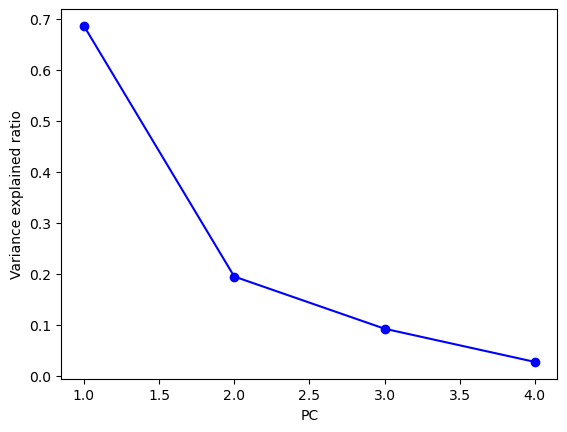

```python
my_screeplot( pca_object )
```

Next, examine the cumulative variance explained plot.

```python
def my_total_variance_explained_plot( pca_object, figsize_use=None ):
    fig, ax = plt.subplots(figsize=figsize_use)

    ax.plot( np.arange(len(pca_object.explained_variance_ratio_) ) + 1 ,
             pca_object.explained_variance_ratio_.cumsum(),
             'bo-' )

    ax.axhline(y=0.5, color='grey', linestyle='--')
    ax.axhline(y=0.8, color='black', linestyle='--')
    ax.axhline(y=0.95, color='red', linestyle='--')

    ax.set_xlabel('PC')
    ax.set_ylabel('Total variance explained')

    plt.show()
```

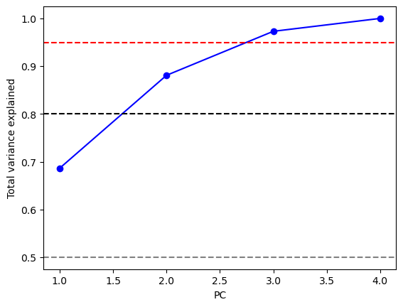

```python
my_total_variance_explained_plot( pca_object )
```

It seems like we should consider between 2 to 3 PCs for this data set!

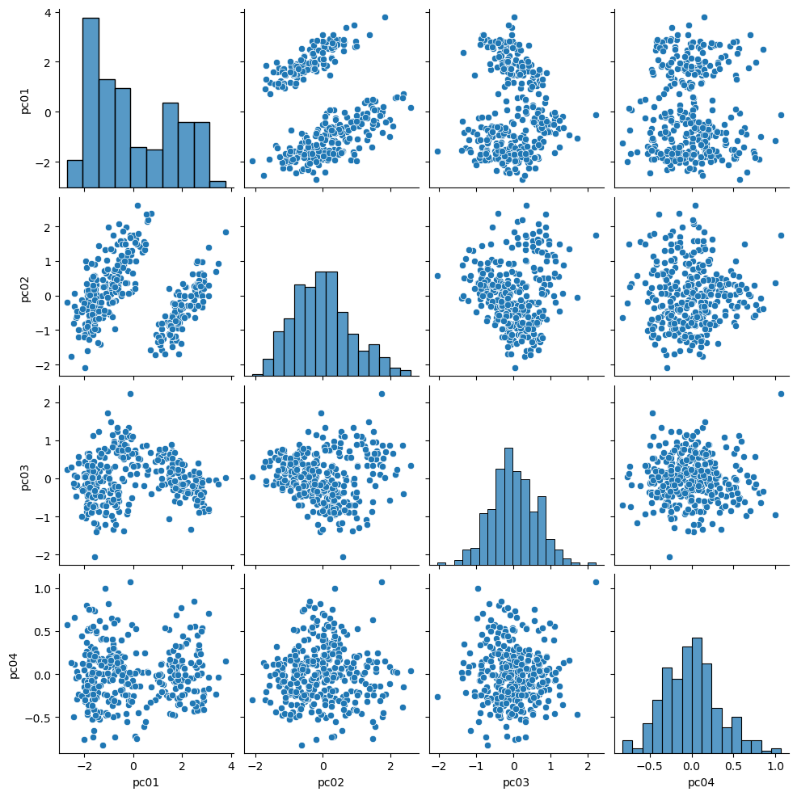

```python
sns.pairplot(data = pc_scores_pens_df)

plt.show()
```

## Interpret PCA - loadings

Interpreeting the loadings allows us to identify which of the original variables are related to the PCs!

```python
def calc_pca_contrib( pca_object, var_names, pc_string='pc' ):
    # square each element in the loadings matrix
    loadings_matrix_sq = pca_object.components_ ** 2
    # sum the square loadings for each PC
    sum_load_squares = loadings_matrix_sq.sum(axis=1)

    # divide the square loadings by the SUM of the squared loadings per PC
    contrib_mat = loadings_matrix_sq.T / sum_load_squares

    # pc labels
    pc_names = ['%s%02d' % (pc_string, d) for d in range(1, sum_load_squares.size + 1)]

    # convert to DataFrame
    res = pd.DataFrame( contrib_mat, columns=pc_names )
    res.index = var_names

    return( res )
```

```python
pens_contrib = calc_pca_contrib( pca_object, pens_features.columns.to_list() )
```

```python
pens_contrib
```

|  | pc01 | pc02 | pc03 | pc04 |
| --- | --- | --- | --- | --- |
| bill_length_mm | 0.205892 | 0.360234 | 0.412800 | 0.021074 |
| bill_depth_mm | 0.159239 | 0.633886 | 0.181306 | 0.025569 |
| flipper_length_mm | 0.332727 | 0.000034 | 0.055741 | 0.611498 |
| body_mass_g | 0.302142 | 0.005847 | 0.350153 | 0.341858 |

```python
pens_contrib.sum(axis=0)
```

```
pc01    1.0
pc02    1.0
pc03    1.0
pc04    1.0
dtype: float64
```

Examine the contributions as a heat map.

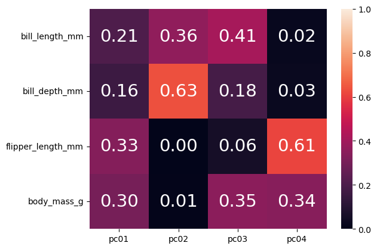

```python
fig, ax = plt.subplots()

sns.heatmap(data = pens_contrib,
            vmin=0, vmax=1,
            annot=True, annot_kws={'fontsize': 21},
            fmt = '1.2f',
            ax=ax)

plt.show()
```

Let's use the UNIFORM THRESHOLD criterion to identify which variables ACTIVELY CONTRIBUTE to each PC.

```python
pens_contrib > ( 1 / pens_features.shape[1] )
```

|  | pc01 | pc02 | pc03 | pc04 |
| --- | --- | --- | --- | --- |
| bill_length_mm | False | True | True | False |
| bill_depth_mm | False | True | False | False |
| flipper_length_mm | True | False | False | True |
| body_mass_g | True | False | True | True |

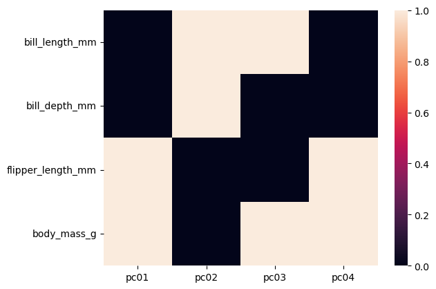

```python
fig, ax = plt.subplots()

sns.heatmap(data = pens_contrib > (1 / pens_features.shape[1] ),
            vmin=0, vmax=1,
            ax=ax)

plt.show()
```

Let's get fine grain detail by examining the biplot.

```python
def my_biplot(scores_df, pca_object, pc_x, pc_y, var_names, pc_string='pc', marker_size_use=11, figsize_use=(9, 9), equal_axis=False):
    # scores_df is a Pandas DataFrame of the PC scores
    # pca_object_use is the PCA().fit() returned object
    #
    # pc_x and pc_y are IDs for the PCs to show on the x and y axes of the plot
    # assumes that PC numbering starts at 1 NOT 0 !!!
    fig, ax = plt.subplots(figsize=figsize_use)

    x_pc_score = scores_df.iloc[:, pc_x-1]
    y_pc_score = scores_df.iloc[:, pc_y-1]
    load_mat = pca_object.components_[[pc_x-1, pc_y-1], :]

    # reference lines
    ax.axhline(y = 0, color='grey')
    ax.axvline(x = 0, color='grey')

    ax.scatter(x_pc_score, y_pc_score, s=marker_size_use)

    # add arrows for the original variables with annotated text
    for i in range(load_mat.shape[1]):
        ax.arrow(0, 0,
                load_mat[0, i] * (x_pc_score.max() - x_pc_score.min()),
                load_mat[1, i] * (y_pc_score.max() - y_pc_score.min()),
                color='r')

        ax.text(load_mat[0, i] * 1.05 * (x_pc_score.max() - x_pc_score.min()),
                load_mat[1, i] * 1.05 * (y_pc_score.max() - y_pc_score.min()),
                var_names[i],
                color = 'black', ha = 'center', va = 'center')

    # variance explained ratio for each PC shown
    pc_x_explain = 100 * pca_object.explained_variance_ratio_[ pc_x-1 ]
    pc_y_explain = 100 * pca_object.explained_variance_ratio_[ pc_y-1 ]

    # labels - IMPORTANT - assumes there are LESS than 100 variables!
    # change to %s%03d if there are 100 to 999 variables
    ax.set_xlabel( '%s%02d (%2.1f%%)' % (pc_string, pc_x, pc_x_explain) )
    ax.set_ylabel( '%s%02d (%2.1f%%)' % (pc_string, pc_y, pc_y_explain) )

    # should the axis ratio be equal?
    if(equal_axis):
        ax.axis('equal')

    plt.show()
```

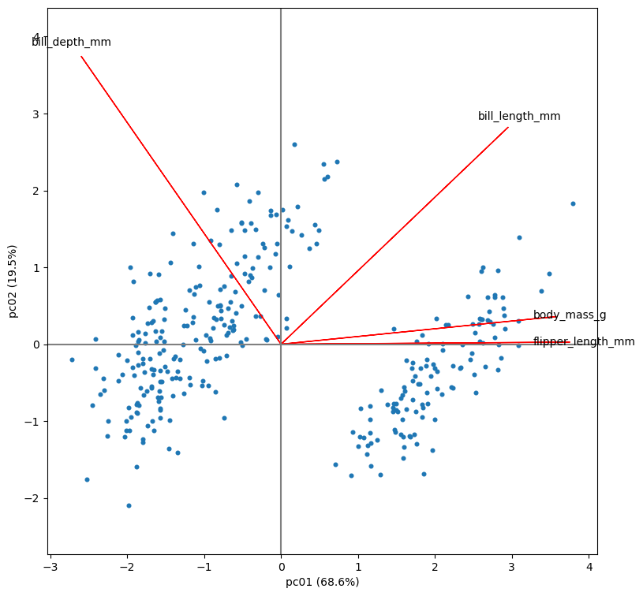

```python
my_biplot(pc_scores_pens_df, pca_object, 1, 2, pens_features.columns.to_list(), equal_axis=True)
```

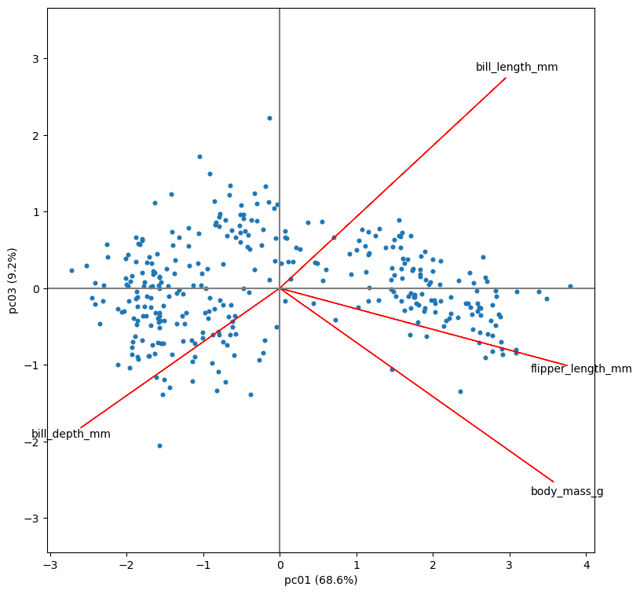

```python
my_biplot(pc_scores_pens_df, pca_object, 1, 3, pens_features.columns.to_list(), equal_axis=True)
```

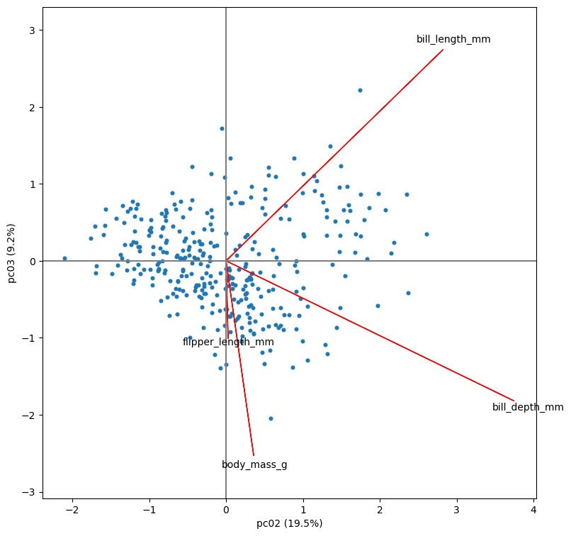

```python
my_biplot(pc_scores_pens_df, pca_object, 2, 3, pens_features.columns.to_list(), equal_axis=True)
```

### Interpret PCA - reconstruction

```python
def my_reconstruction(num_components, features_df, undo_stan=False):
    # features_df is a Pandas DataFrame

    # standardize
    stan_object = StandardScaler().fit( features_df )
    X = stan_object.transform( features_df )

    # execute PCA
    pca_obj = PCA(n_components=num_components).fit( X )

    # reconstruct the original variables based on the assumed number of PCs
    Xhat = pca_obj.inverse_transform( pca_obj.transform( X ) )

    if undo_stan:
        # undo the standardization to return to the original magnitude/scale
        Xhat = stan_object.inverse_transform( Xhat )

    # convert to a pandas dataframe
    features_hat_df = pd.DataFrame( Xhat, columns=features_df.columns )

    return( features_hat_df )
```

```python
my_reconstruction(1, pens_features)
```

|  | bill_length_mm | bill_depth_mm | flipper_length_mm | body_mass_g |
| --- | --- | --- | --- | --- |
| 0 | -0.841074 | 0.739671 | -1.069199 | -1.018873 |
| 1 | -0.597254 | 0.525248 | -0.759248 | -0.723512 |
| 2 | -0.624639 | 0.549330 | -0.794060 | -0.756685 |
| 3 | -0.855456 | 0.752319 | -1.087481 | -1.036295 |
| 4 | -0.871197 | 0.766163 | -1.107493 | -1.055365 |
| ... | ... | ... | ... | ... |
| 328 | 0.906470 | -0.797183 | 1.152332 | 1.098094 |
| 329 | 0.831571 | -0.731314 | 1.057119 | 1.007362 |
| 330 | 1.248504 | -1.097980 | 1.587137 | 1.512433 |
| 331 | 0.777667 | -0.683909 | 0.988594 | 0.942062 |
| 332 | 0.915917 | -0.805492 | 1.164343 | 1.109539 |

333 rows × 4 columns

```python
def tidy_my_reconstruction(num_components, features_df, undo_stan=False):
    # features_df is a Pandas DataFrame

    features_hat_df = my_reconstruction(num_components, features_df, undo_stan )

    # reshape to long format
    lfhat = features_hat_df.reset_index().rename(columns={'index':'rowid'}).\
    melt(id_vars=['rowid'], value_vars=features_hat_df.columns, value_name='Reconstructed value')

    # reshape the original features to long format
    if undo_stan:
        # use the original feature values directly
        lf = features_df.reset_index().rename(columns={'index': 'rowid'}).\
        melt(id_vars=['rowid'], value_vars=features_df.columns, value_name='Feature value')
    else:
        # use the standardized feature values instead
        lf = pd.DataFrame(StandardScaler().fit_transform( features_df ), columns=features_df.columns).\
        reset_index().rename(columns={'index': 'rowid'}).\
        melt(id_vars=['rowid'], value_vars=features_df.columns, value_name='Feature value')

    # join the reconstructed and original feature value
    res = pd.merge( lfhat, lf, on=['rowid', 'variable'], how='left')

    res['num_components'] = num_components

    return(res)
```

```python
tidy_my_reconstruction(1, pens_features)
```

|  | rowid | variable | Reconstructed value | Feature value | num_components |
| --- | --- | --- | --- | --- | --- |
| 0 | 0 | bill_length_mm | -0.841074 | -0.896042 | 1 |
| 1 | 1 | bill_length_mm | -0.597254 | -0.822788 | 1 |
| 2 | 2 | bill_length_mm | -0.624639 | -0.676280 | 1 |
| 3 | 3 | bill_length_mm | -0.855456 | -1.335566 | 1 |
| 4 | 4 | bill_length_mm | -0.871197 | -0.859415 | 1 |
| ... | ... | ... | ... | ... | ... |
| 1327 | 328 | body_mass_g | 1.098094 | 0.892957 | 1 |
| 1328 | 329 | body_mass_g | 1.007362 | 0.799674 | 1 |
| 1329 | 330 | body_mass_g | 1.512433 | 1.919069 | 1 |
| 1330 | 331 | body_mass_g | 0.942062 | 1.234995 | 1 |
| 1331 | 332 | body_mass_g | 1.109539 | 1.483749 | 1 |

1332 rows × 5 columns

```python
def viz_my_reconstruction(num_components, features_df, undo_stan=False, col_wrap=None):
    if undo_stan:
        sharex_use = False
        sharey_use = False
    else:
        sharex_use = True
        sharey_use = True

    sns.relplot(data = tidy_my_reconstruction( num_components, features_df, undo_stan ),
                x='Feature value', y='Reconstructed value',
                col='variable', col_wrap=col_wrap,
                facet_kws={'sharex': sharex_use, 'sharey': sharey_use})

    plt.show()
```

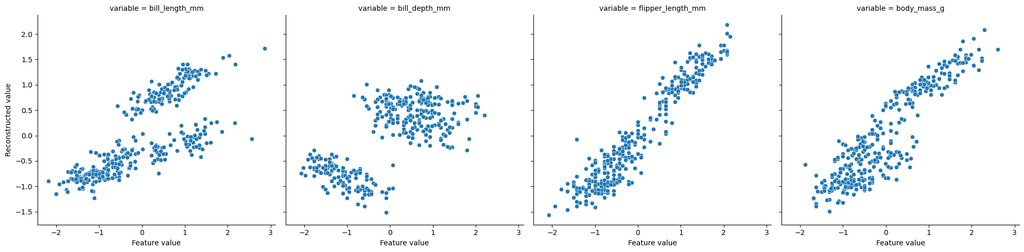

```python
viz_my_reconstruction(1, pens_features)
```

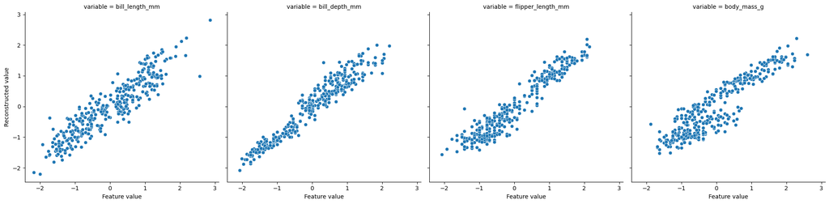

```python
viz_my_reconstruction(2, pens_features)
```

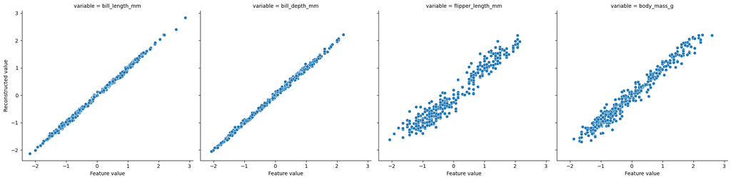

```python
viz_my_reconstruction(3, pens_features)
```

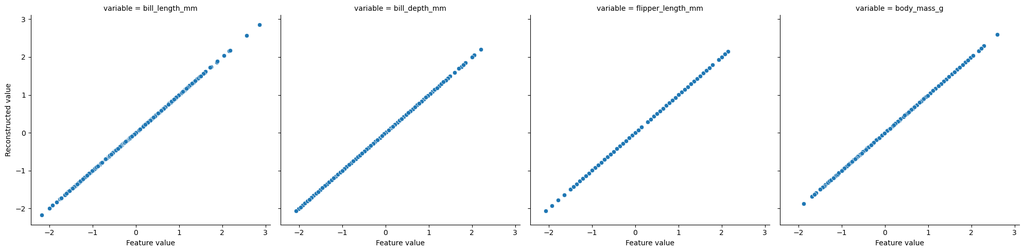

```python
viz_my_reconstruction(4, pens_features)
```

## Summary

Definitely need the first 2 PCs, but could argue the first 3 PCs are necessary to approximate these 4 features!